# Ejemplo de resultados con RMarkdown

Curso electivo: Ciencia Abierta y Software Libre

Felipe Ruiz

03-06-2020

# Ejemplo de exportación de resultados

A continuación ingresaremos los diferentes elementos ya calculados en la *sintaxis sesión 10* a un reporte reproducible. La única diferencia respecto al cálculo sobre la sintaxis de R es que estamos agregando un argumento adicional de tipo *style = “rmarkdown”, que le indica al programa que debe imprimir la tabla en un resultado procesable por esta plataforma.

Desde este reporte en formato *Html* podemos copiar cualquier tabla y copiarla a un editor de planillas o texto: Microsoft Excel, Microsoft Word, Libre/Open Writer, Libre/Open Calc, Google Docs, Google Sheets, entre otros.

## Resultado 1

Cálculo de frecuencias **ponderadas** con función *freq* del paquete **summarytools**: posición ante manifestaciones de Octubre del año 2019.

```r
freq(CEP$O19_rec, weights = CEP$pond,
     style = "rmarkdown")
```

### Weighted Frequencies

#### CEP$O19_rec

**Type:** Factor  
**Weights:** pond

|  | Freq | % Valid | % Valid Cum. | % Total | % Total Cum. |
| --- | --- | --- | --- | --- | --- |
| **Apruebo** | 926.54 | 63.40 | 63.40 | 61.93 | 61.93 |
| **Neutro** | 230.39 | 15.77 | 79.17 | 15.40 | 77.34 |
| **Rechazo** | 304.39 | 20.83 | 100.00 | 20.35 | 97.68 |
| **<NA>** | 34.68 |  |  | 2.32 | 100.00 |
| **Total** | 1496.00 | 100.00 | 100.00 | 100.00 | 100.00 |

## Resultado 2

Cálculo de una tabla de contingencia - doble entrada - con frecuencias **ponderadas** mediante la función *ctable* del paquete **summarytools**: posición ante manifestaciones de Octubre del año 2019 según sexo (perfil columna).

```r
ctable(CEP$sexorec, CEP$O19_rec, prop = "c",
       weights = CEP$pond,
       style = "rmarkdown")
```

### Cross-Tabulation, Column Proportions

#### sexorec * O19_rec

**Data Frame:** CEP

|  | O19_rec | Apruebo | Neutro | Rechazo | <NA> | Total |
| --- | --- | --- | --- | --- | --- | --- |
| sexorec |  |  |  |  |  |  |
| hombre |  | 466.8 ( 50.4%) | 93.2 ( 40.5%) | 147.6 ( 48.5%) | 14.6 ( 42.0%) | 722.2 ( 48.3%) |
| mujer |  | 459.7 ( 49.6%) | 137.2 ( 59.5%) | 156.8 ( 51.5%) | 20.1 ( 58.0%) | 773.8 ( 51.7%) |
| Total |  | 926.5 (100.0%) | 230.4 (100.0%) | 304.4 (100.0%) | 34.7 (100.0%) | 1496.0 (100.0%) |

## Resultado 3

Cálculo de estadísticos de resumen **ponderados** de la variable *edad*, mediante la función *descr* del paquete **summarytools**.

```r
descr(CEP$edad, transpose = T,
      stats = "common", weights = CEP$pond)
```

Weighted Descriptive Statistics  
CEP$edad  
Weights: pond  
N: 1496

|  | Mean | Std.Dev | Min | Median | Max | N.Valid | Pct.Valid |
| --- | --- | --- | --- | --- | --- | --- | --- |
| edad | 44.26 | 17.48 | 18.00 | 42.00 | 99.00 | 1496.00 | 100.00 |

## Resultado 4

Cálculo de estadísticos de resumen **ponderados** de la variable *edad*, según las categorías de la variable *posición ante manifestaciones de Octubre del año 2019*, mediante la función *descr* del paquete **summarytools**.

Acá se usa una función *with*, para ejecutar un *stby*: cálculo de estadísticos de resumen, según grupos de una segunda variable.

```r
with(CEP, stby(data= edad, INDICES = O19_rec,
                        FUN = descr,
                        stats = "common", weights = CEP$pond,
                        transpose = T))
```

Weighted Descriptive Statistics  
edad by O19_rec  
Data Frame: CEP  
Weights: pond  
N: 872

|  | Mean | Std.Dev | Min | Median | Max | N.Valid | Pct.Valid |
| --- | --- | --- | --- | --- | --- | --- | --- |
| Apruebo | 43.78 | 16.73 | 18.00 | 42.00 | 93.00 | 834.23 | 55.76 |
| Neutro | 53.78 | 18.41 | 18.00 | 56.00 | 99.00 | 241.75 | 16.16 |
| Rechazo | 55.46 | 17.90 | 18.00 | 57.83 | 91.00 | 323.66 | 21.64 |

## Resultado 5

Gráfica construida con herramientas básicas de R.

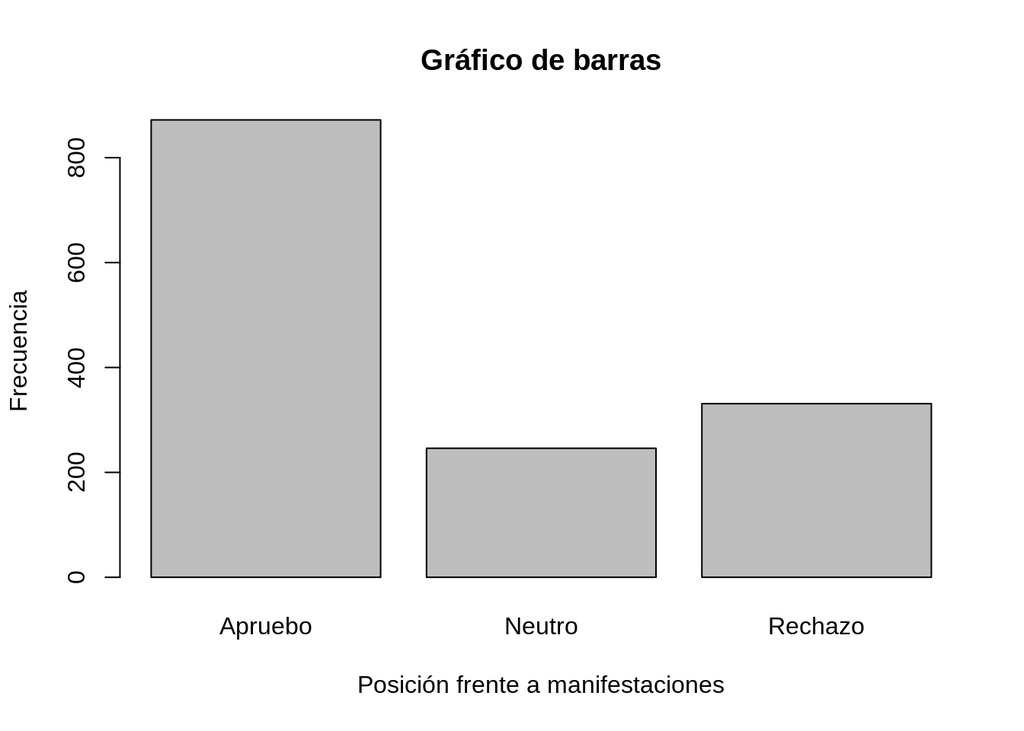

```r
plot(CEP$O19_rec, ylab = "Frecuencia", xlab = "Posición frente a manifestaciones",
     main = "Gráfico de barras")
```

## Resultado 6

Gráfica construida con herramientas avanzadas y especializada en esa área: paquete *ggplot2*.

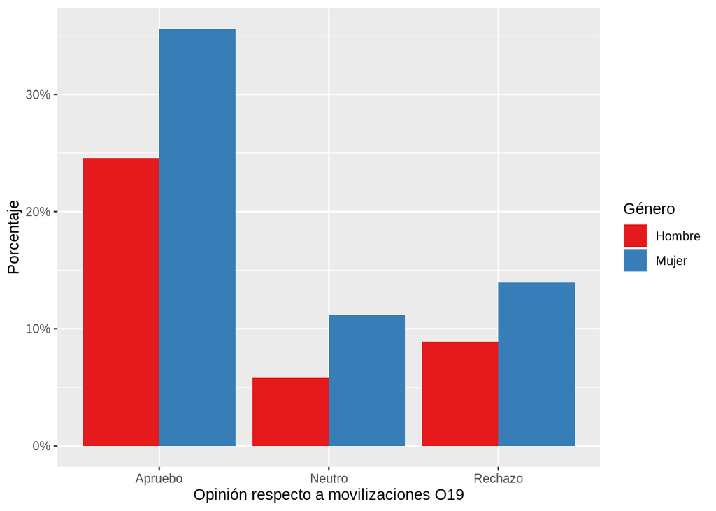

```r
CEP %>%
  filter(!is.na(O19_rec)) %>%
  ggplot() +
  geom_bar(mapping = aes(x = O19_rec, y = (..count..)/sum(..count..), fill = factor(sexorec)),
           position = "dodge") + # Probar sacando "position"
  scale_y_continuous(labels=scales::percent) +
  xlab("Opinión respecto a movilizaciones O19") +
  scale_fill_manual("Género",
                    values = c("#E41A1C", "#377EB8"),
                    labels = c("Hombre", "Mujer")) +
  ylab("Porcentaje")
```